# Plate-boundary segments: structure feasibility, seismicity style and figure plan

Draft for the Science Advances re-framing (D-B107, PI 2026-11-26 16:05). Built Thu Nov 26 16:32:54 PST 2026; branch `analysis/plate-boundaries` at `cecab0a5` (worktree /home/mdenolle/wt_pbplan). Private working page; not peer reviewed. Catalog v6.0 is used as a stand-in: v6.1 (D-B103, D-B105) replaces it in the paper and every number here is to be recomputed on it.

**What this page answers.** D-B107 asks for a paper on fault-zone structure and seismicity style at the plate boundaries, with velocity structure shown only near faults and only where the model resolves it. Before figures are drawn: which boundaries does model v0.4.2 resolve, how large is the ensemble uncertainty there, how large are the structure contrasts against it, and how do the boundaries differ in seismicity style? Section 5 is the figure plan; draft mock-ups are in sections 4 and 6.

## 1. Findings

- **Coverage.** The rule below sorts 135,954 located tier A-C earthquakes of v6.0 (flagged non-earthquakes and the waveform-review P1 set left out) into 21 segments, 19 of them on plate boundaries. No tomography tile covers the model columns of Axial Seamount, Endeavour or the Explorer segments (n_tiles = 0, DWS = 0), and the JdF plate interior lies at the tile edges (largest P DWS 84 in its columns). So AX, EN, EXR, SOV, JP, EXP have no resolved node; their style metrics stand alone.
- **Resolved for a fault-zone panel** (≥ 15 P and ≥ 10 P-and-S nodes within 10 km over ≥ 3 depth layers): BL, MFZ, GP, MTJ, GS, PU, MSH, CAS (plus the non-boundary groups OC and NAPA). **Marginal**: JR, GR, FA, SIF, IS (Gorda ridge and the northern subduction groups have P nodes only, FA 2 P-and-S nodes; JR has 13 P nodes at 5-7 km). The P-and-S depth span is 9-29 km at Blanco, 18-34 km at the Mendocino fault zone, 21-34 km in the Gorda plate, 9-29 km at the triple junction, 5-25 km in Puget crust and 1-21 km at Mount St Helens.
- **Scale.** The finest checkerboard cell that passes near every segment is 40 km, and most near-fault nodes pass the mask on ray sampling alone (DWS ≥ 100): the checkerboard share within 10 km is 28% (P) and 65% (S) at Blanco, 57% at Mount St Helens, 13% in Puget and below 10 % at MFZ, Gorda plate, MTJ and the Gorda slab. The panels can show the structure of the plate-boundary zone on a 40 km scale, not a fault damage zone. Figure captions and the text have to say this.
- **Ensemble 1σ near the faults** (median over nodes within 10 km, calibrated): Vp 0.10 km/s at Mount St Helens to 0.28 km/s at Blanco; Vp/Vs 0.030 to 0.083 (raw spread x 1.5, no calibrated factor exists for Vp/Vs). The Blanco tile (smoothing 20) has the largest member spread.
- **Contrasts against the ensemble.** A depth-matched contrast recomputed in each member has a much smaller spread than the node 1σ (node errors are correlated in space), so both ratios are given. Of the 105 contrasts on resolved and marginal segments, 34 exceed 2σ of the members and 27 exceed the node 1σ. Blanco has none at 2σ (largest 1.8σ). Vp/Vs reaches 2σ only along the Cascade arc. Inside-zone minus 10-20 km surroundings (near-far) at ≥ 2σ: GR Vp -0.21 km/s (3.8σ); MFZ Vp -0.08 km/s (2.3σ); MFZ Vs -0.11 km/s (4.4σ); MTJ Vp +0.23 km/s (6.5σ); MTJ Vs +0.13 km/s (4.0σ); GS Vs -0.20 km/s (5.7σ); FA Vp -0.24 km/s (4.7σ); IS Vp +0.38 km/s (2.8σ); PU Vp -0.05 km/s (2.1σ); MSH Vs -0.06 km/s (2.5σ); CAS Vp +0.09 km/s (3.0σ); OC Vp +0.09 km/s (2.6σ); NAPA Vs -0.13 km/s (3.5σ). The largest values (0.4-0.6 km/s along strike at MTJ and in the Gorda slab) follow the onshore-offshore transition, not a fault zone.
- **Seismicity style** separates the boundary types more clearly than structure does. Swarm share of the events above Mc: Axial 31 %, Mount St Helens 38 %, Blanco 24 %, Gorda ridge 21 %, against ≤ 3.4 % at MFZ, Gorda plate, MTJ and the Gorda slab. Mainshock-aftershock share is highest in the Gorda plate (64 %). b-values range from 0.76 (JdF intraslab) and 0.80 (Axial) to 1.44 (Puget crust). Median depth below the surface: Axial 1.9 km, Blanco 5.8 km, Mount St Helens 6.2 km, Puget 15.7 km, Gorda slab 21.7 km, MTJ 24.1 km, MFZ 24.8 km.
- **Depth against the 7.5 km/s level.** The model rarely reaches 8 km/s offshore (MFZ peaks near 7.9 km/s), so the 8 km/s level is resolved in few columns; 7.5 km/s is resolved for 95% of the depth-good Blanco events and 97% at MTJ. Share of events below it: MFZ 71%, Gorda plate 58%, MTJ 54%, Blanco 39%, Gorda slab 24%. Per model column, the bottom of the Gorda-slab seismicity (D90) follows the 7.5 km/s level (ρ = 0.52, p = 0.001 against permuted levels, 64 columns); at Blanco the link is weak (ρ = 0.12, p = 0.046); at MFZ none.
- **Swarms against mainshock-aftershock families** can be compared on resolved nodes only at Blanco (Vp/Vs: 9 swarm against 32 MA families) and in Puget (7 against 13). Neither differs (p ≥ 0.1 for Vp and Vp/Vs), as in the v5.1 analysis. A panel on this would report a null result with few families.

## 2. Segment rule and segment table

Rule (code `workflow/11_paper_plan/pb_common.py`, first match wins):

1. Located events of catalog v6.0 (any tier), first match wins; distances are horizontal.
2. AX: catalog region Axial. BL: catalog region Blanco. EN: catalog region Endeavour.
3. MTJ: within 40 km of the PB2002 triple junction (southern end of the JF\NA subduction trace).
4. MFZ: within 15 km of a PB2002 PA-JF transform step, south of 41 N.
5. Ridges: within 15 km of a PB2002 PA-JF spreading-ridge step: GR south of 43 N, JR 43-48.35 N, EXR north of 48.35 N.
6. Explorer region, rest: SOV within 15 km of a transform step, else EXP.
7. West of the PB2002 subduction trace (oceanic plate): GP south of 43 N, JP north of it.
8. South of the triple junction latitude (outside MTJ and MFZ): NAPA.
9. East of the trace, by depth relative to Slab2 (rel = depth - slab): Cascades region: MSH within 25 km of the summit, else CAS. Puget/Georgia and Other onshore: crust (PU, OC) if rel < -10 km or no Slab2. Every other event east of the trace: GS south of 41.5 N; north of it IS if rel >= +5 km, SIF if |rel| < 5 km, FA otherwise (also without Slab2).

Events: located earthquakes of v6.0 (event_flag empty), tiers A-C, review P1 (Mount St Helens weekly-signal candidates, 198 tier A-C events) left out. Fault surfaces v1 belong to the segment of most of their fit members at the v6.0 positions (table `surface_segments.csv`; 117 of 142 surfaces have ≥ 80 % of their members in one segment). Threshold sensitivity is in section 7.

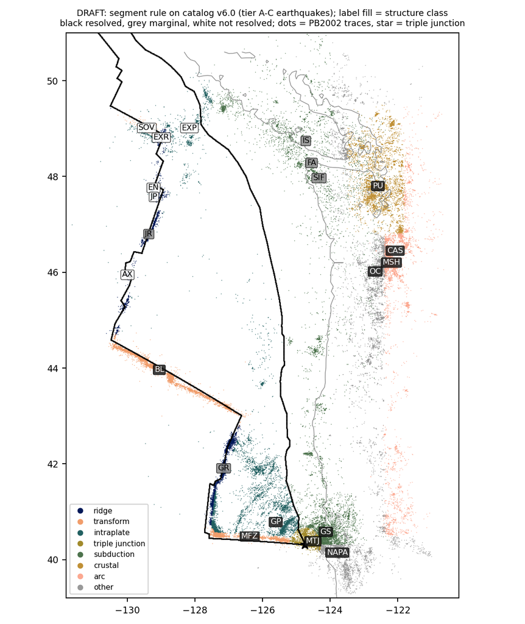

Segments on catalog v6.0 (tier A-C earthquakes, coloured by type) with the structure class of each segment (label fill: black resolved, grey marginal, white not resolved). Coastline: zero contour of the model surface. Draft.

Segment table. Structure class: section 3. Depth class from the depth-good events: good (median σz ≤ 3 km), fair (3-6 km), none (fewer than 50 depth-good events). Shares are of the events above the clustering Mc (v6.0 nearest- neighbour run). Migrating swarms: zbz swarm families ≥ 10 events + DBSCAN swarm-like clusters flagged migrating.

| seg | segment | type | events A-C | depth | structure | P / PS nodes ≤10 km | PS depth span (km) | checkerboard share P | Mc | b [95 % CI] | background % | MA % | swarm % | depth below surface p50 / p90 (km) | below 7.5 km/s | surfaces (dip) | migrating swarms | burstiness |
| --- | --- | --- | --- | --- | --- | --- | --- | --- | --- | --- | --- | --- | --- | --- | --- | --- | --- | --- |
| AX | Axial Seamount (JdF ridge) | ridge | 20,996 | good | not resolved | 0 / 0 | – | – | 0.35 | 0.80 [0.72, 0.82] | 50 | 14 | 31 | 1.9 / 2.5 | – | 0 | 2 + 0 | 0.88 |
| JR | JdF ridge, other segments | ridge | 1,267 | none | marginal | 13 / 0 | – | 0.00 | 1.95 | 1.29 [1.09, 1.53] | 56 | 12 | 13 | – | – | 2 (74°) | 0 + 0 | 0.61 |
| EN | Endeavour segment | ridge | 89 | none | not resolved | 0 / 0 | – | – | 1.75 | 0.74 | – | – | – | – | – | 0 | 0 + 0 | 0.35 |
| EXR | Explorer ridge | ridge | 199 | none | not resolved | 0 / 0 | – | – | 1.95 | 1.03 [0.72, 1.32] | 64 | 21 | 10 | – | – | 1 (63°) | 0 + 0 | 0.33 |
| GR | Gorda ridge | ridge | 3,096 | fair | marginal | 136 / 0 | – | 0.00 | 2.05 | 1.39 [1.24, 1.53] | 43 | 22 | 21 | 10.5 / 21.6 | – | 12 (62°) | 1 + 0 | 0.59 |
| BL | Blanco transform | transform | 36,665 | fair | resolved | 937 / 324 | 9-29 | 0.28 | 1.75 | 1.19 [1.14, 1.21] | 48 | 18 | 24 | 5.8 / 18.6 | 0.39 | 18 (86°) | 3 + 10 | 0.67 |
| MFZ | Mendocino fault zone | transform | 2,742 | fair | resolved | 203 / 61 | 18-34 | 0.00 | 2.05 | 0.98 [0.90, 1.07] | 76 | 20 | 1 | 24.8 / 35.1 | 0.71 | 3 (76°) | 0 + 0 | 0.56 |
| SOV | Sovanco transform | transform | 95 | none | not resolved | 0 / 0 | – | – | 2.25 | – | 91 | 9 | 0 | – | – | 0 | 0 + 0 | 0.09 |
| JP | JdF plate interior | intraplate | 607 | fair | not resolved | 0 / 0 | – | – | 1.95 | 1.11 [0.93, 1.32] | 50 | 36 | 6 | 27.8 / 42.0 | – | 0 | 0 + 0 | 0.29 |
| GP | Gorda plate interior | intraplate | 6,078 | fair | resolved | 410 / 100 | 21-34 | 0.08 | 1.95 | 1.21 [1.06, 1.29] | 33 | 64 | 1 | 16.6 / 26.3 | 0.58 | 16 (71°) | 0 + 0 | 0.46 |
| EXP | Explorer plate / Nootka | intraplate | 875 | none | not resolved | 0 / 0 | – | – | 2.05 | 0.87 [0.77, 0.98] | 39 | 57 | 1 | – | – | 4 (70°) | 0 + 0 | 0.44 |
| MTJ | Mendocino triple junction | triple junction | 10,574 | good | resolved | 410 / 221 | 9-29 | 0.06 | 1.35 | 0.92 [0.88, 0.95] | 64 | 31 | 1 | 24.1 / 30.9 | 0.54 | 6 (41°) | 0 + 1 | 0.13 |
| GS | Gorda slab beneath the margin (S of 41.5 N) | subduction | 11,994 | good | resolved | 693 / 178 | 9-29 | 0.08 | 1.35 | 1.08 [1.05, 1.12] | 68 | 23 | 3 | 21.7 / 30.6 | 0.24 | 12 (45°) | 0 + 0 | 0.21 |
| FA | Forearc upper plate (N of 41.5 N) | subduction | 1,871 | fair | marginal | 234 / 2 | – | 0.00 | 1.45 | 1.33 [1.16, 1.49] | 69 | 9 | 9 | 10.9 / 21.1 | 0.00 | 7 (58°) | 0 + 0 | 0.19 |
| SIF | Interface zone (N of 41.5 N) | subduction | 1,354 | good | marginal | 156 / 0 | – | 0.00 | 1.45 | 1.08 [0.99, 1.19] | 87 | 7 | 3 | 27.3 / 47.5 | 0.19 | 1 (76°) | 0 + 0 | 0.08 |
| IS | JdF intraslab (N of 41.5 N) | subduction | 1,195 | fair | marginal | 76 / 0 | – | 0.00 | 1.75 | 0.76 [0.69, 0.84] | 65 | 29 | 3 | 38.1 / 61.5 | 0.98 | 2 (75°) | 0 + 0 | 0.15 |
| PU | Puget-Georgia crust | crustal | 11,376 | good | resolved | 1358 / 228 | 5-25 | 0.13 | 1.25 | 1.44 [1.30, 1.55] | 74 | 14 | 5 | 15.7 / 23.4 | – | 19 (50°) | 0 + 0 | 0.05 |
| MSH | Mount St Helens | arc | 7,858 | good | resolved | 264 / 161 | 1-21 | 0.57 | 0.35 | 0.97 [0.88, 1.00] | 37 | 13 | 38 | 6.2 / 15.3 | – | 4 (60°) | 1 + 0 | 0.14 |
| CAS | Cascade arc, other | arc | 5,107 | good | resolved | 704 / 243 | 1-21 | 0.25 | 1.45 | 1.17 [1.01, 1.25] | 65 | 10 | 15 | 12.9 / 21.6 | – | 10 (60°) | 0 + 0 | 0.12 |
| OC | Other onshore crust | other | 7,547 | good | resolved | 1158 / 234 | 1-21 | 0.20 | 1.05 | 1.10 [1.07, 1.22] | 81 | 10 | 2 | 14.9 / 22.6 | 0.00 | 17 (54°) | 0 + 0 | 0.09 |
| NAPA | North America-Pacific, south of the MTJ | other | 4,369 | good | resolved | 214 / 71 | 9-29 | 0.00 | 1.35 | 0.87 [0.83, 0.92] | 76 | 13 | 2 | 23.1 / 32.4 | 0.28 | 8 (55°) | 0 + 0 | 0.25 |

## 3. Structure feasibility

Model v0.4.2 on its node grid (0.125° x 0.1°, about 10 x 11 km; depth nodes 2-6 km apart above 30 km). Masks as used so far: rock and (checkerboard-resolved or DWS ≥ 100), P for Vp, S for Vs, both for Vp/Vs; nodes whose Vs was reverted to the reference (D-B051) are left out of the S mask. Distance of a node: 3-D distance to the nearest point of the segment's fault surfaces (1 km mesh) or of its seismicity (depth-good events where there are ≥ 50, else tier A-C). Ensemble 1σ: v0.4.2+ens.100 Vp_std (x 1.50) and Vs_std (x 1.35) as stored; Vp/Vs: the raw member std x 1.50. Class: **resolved** ≥ 15 P and ≥ 10 P-and-S nodes within 10 km over ≥ 3 depth layers; **marginal** ≥ 5 P nodes within 10 km; else **not resolved**. Spans list depth layers with ≥ 3 nodes.

| seg | type | surfaces | reference events | nP_5 | nP_10 | nP_20 | nS_10 | nPS_5 | nPS_10 | nPS_20 | P span (km) | PS span (km) | cb share P | cb share S | cb cell (km) | 1σ Vp | 1σ Vs | 1σ Vp/Vs | events on P nodes | events on PS nodes | max \|Δ\|/σ | class |
| --- | --- | --- | --- | --- | --- | --- | --- | --- | --- | --- | --- | --- | --- | --- | --- | --- | --- | --- | --- | --- | --- | --- |
| AX | ridge | 0 | depth-good | 0 | 0 | 0 | 0 | 0 | 0 | 0 | – | – | – | – | – | – | – | – | 0.00 | 0.00 | – | not resolved |
| JR | ridge | 2 | tier A-C | 5 | 13 | 29 | 0 | 0 | 0 | 0 | 5-7 | – | 0.00 | – | – | 0.240 | – | – | 0.03 | 0.00 | 1.0 | marginal |
| EN | ridge | 0 | tier A-C | 0 | 0 | 0 | 0 | 0 | 0 | 0 | – | – | – | – | – | – | – | – | 0.00 | 0.00 | – | not resolved |
| EXR | ridge | 1 | tier A-C | 0 | 0 | 0 | 0 | 0 | 0 | 0 | – | – | – | – | – | – | – | – | 0.00 | 0.00 | – | not resolved |
| GR | ridge | 12 | depth-good | 87 | 136 | 191 | 0 | 0 | 0 | 0 | 9-34 | – | 0.00 | – | – | 0.194 | – | – | 0.44 | 0.00 | 3.8 | marginal |
| BL | transform | 18 | depth-good | 623 | 937 | 1,138 | 329 | 232 | 324 | 379 | 3-40 | 9-29 | 0.28 | 0.65 | 40 | 0.282 | 0.159 | 0.083 | 0.77 | 0.30 | 1.8 | resolved |
| MFZ | transform | 3 | depth-good | 126 | 203 | 304 | 61 | 49 | 61 | 96 | 15-40 | 18-34 | 0.00 | 0.00 | – | 0.210 | 0.095 | 0.048 | 0.80 | 0.35 | 4.4 | resolved |
| SOV | transform | 0 | tier A-C | 0 | 0 | 0 | 0 | 0 | 0 | 0 | – | – | – | – | – | – | – | – | 0.00 | 0.00 | – | not resolved |
| JP | intraplate | 0 | depth-good | 0 | 0 | 4 | 0 | 0 | 0 | 0 | – | – | – | – | – | – | – | – | 0.00 | 0.00 | – | not resolved |
| GP | intraplate | 16 | depth-good | 228 | 410 | 640 | 100 | 70 | 100 | 161 | 9-40 | 21-34 | 0.08 | 0.00 | 40 | 0.186 | 0.083 | 0.042 | 0.60 | 0.35 | 4.7 | resolved |
| EXP | intraplate | 4 | tier A-C | 0 | 0 | 0 | 0 | 0 | 0 | 0 | – | – | – | – | – | – | – | – | 0.00 | 0.00 | – | not resolved |
| MTJ | triple junction | 6 | depth-good | 289 | 410 | 602 | 221 | 172 | 221 | 268 | 1-34 | 9-29 | 0.06 | 0.00 | 40 | 0.163 | 0.089 | 0.047 | 0.94 | 0.82 | 8.4 | resolved |
| GS | subduction | 12 | depth-good | 524 | 693 | 866 | 178 | 136 | 178 | 232 | 1-40 | 9-29 | 0.08 | 0.00 | 40 | 0.171 | 0.091 | 0.047 | 0.88 | 0.61 | 10.8 | resolved |
| FA | subduction | 7 | depth-good | 86 | 234 | 608 | 2 | 0 | 2 | 45 | 1-29 | – | 0.00 | 0.00 | – | 0.191 | 0.106 | 0.052 | 0.25 | 0.00 | 4.7 | marginal |
| SIF | subduction | 1 | depth-good | 92 | 156 | 393 | 0 | 0 | 0 | 6 | 12-47 | – | 0.00 | – | – | 0.222 | – | – | 0.23 | 0.00 | 1.0 | marginal |
| IS | subduction | 2 | depth-good | 17 | 76 | 176 | 0 | 0 | 0 | 0 | 18-65 | – | 0.00 | – | – | 0.223 | – | – | 0.11 | 0.00 | 2.8 | marginal |
| PU | crustal | 19 | depth-good | 1,083 | 1,358 | 1,489 | 228 | 183 | 228 | 247 | 1-34 | 5-25 | 0.13 | 0.00 | 40 | 0.124 | 0.086 | 0.043 | 0.73 | 0.33 | 4.6 | resolved |
| MSH | arc | 4 | depth-good | 177 | 264 | 414 | 161 | 119 | 161 | 205 | -1-21 | 1-21 | 0.57 | 0.00 | 40 | 0.095 | 0.049 | 0.030 | 0.97 | 0.83 | 2.5 | resolved |
| CAS | arc | 10 | depth-good | 383 | 704 | 1,093 | 243 | 153 | 243 | 327 | -1-25 | 1-21 | 0.25 | 0.00 | 40 | 0.131 | 0.056 | 0.032 | 0.53 | 0.33 | 3.0 | resolved |
| OC | other | 17 | depth-good | 718 | 1,158 | 1,721 | 234 | 184 | 234 | 352 | 1-29 | 1-21 | 0.20 | 0.00 | 40 | 0.139 | 0.059 | 0.033 | 0.63 | 0.33 | 8.0 | resolved |
| NAPA | other | 8 | depth-good | 152 | 214 | 315 | 71 | 53 | 71 | 106 | 1-40 | 9-29 | 0.00 | 0.00 | – | 0.170 | 0.094 | 0.048 | 0.68 | 0.45 | 4.2 | resolved |

### Contrasts against the ensemble

Depth-matched contrasts (per depth layer, weighted by the smaller node count): *near-far* = nodes within 5 km minus nodes 10-20 km away; *across* = the two sides of the segment's strike line (PCA of its epicentres; nodes within 3 km of the line left out; + = left of the strike direction); *along* = the third of the nodes within 10 km at the strike-azimuth end (strike 0-180°, `segment_axes.csv`) minus the third at the other end. σ of Δ: the same contrast in each of the 100 members, std x calibration factor. "members same sign" = share of members whose contrast has the sign of the v0.4.2 value.

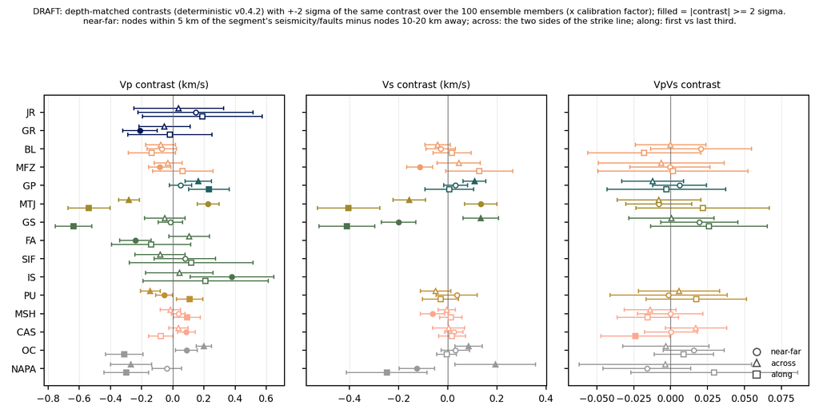

Depth-matched contrasts of the resolved and marginal segments with ±2σ of the member contrasts; filled where |Δ| ≥ 2σ. Colours by segment type. Draft.

| seg | var | contrast | n1 | n2 | Δ (v0.4.2) | σ of Δ (members) | \|Δ\|/σ | members same sign | node 1σ | \|Δ\|/node 1σ |
| --- | --- | --- | --- | --- | --- | --- | --- | --- | --- | --- |
| JR | Vp | across | 7 | 15 | +0.039 | 0.144 | 0.3 | 0.63 | 0.240 | 0.16 |
| JR | Vp | along | 5 | 5 | +0.190 | 0.192 | 1.0 | 0.91 | 0.242 | 0.78 |
| JR | Vp | near-far | 5 | 16 | +0.147 | 0.185 | 0.8 | 0.87 | 0.240 | 0.61 |
| GR | Vp | across | 71 | 91 | -0.054 | 0.082 | 0.7 | 0.78 | 0.198 | 0.27 |
| GR | Vp | along | 48 | 48 | -0.018 | 0.135 | 0.1 | 0.56 | 0.205 | 0.09 |
| GR | Vp | near-far | 87 | 55 | -0.210 | 0.055 | 3.8 | 1.00 | 0.197 | 1.06 |
| BL | Vp | across | 462 | 541 | -0.077 | 0.048 | 1.6 | 0.98 | 0.288 | 0.27 |
| BL | Vp | along | 317 | 314 | -0.134 | 0.076 | 1.8 | 1.00 | 0.293 | 0.46 |
| BL | Vp | near-far | 623 | 201 | -0.070 | 0.047 | 1.5 | 0.96 | 0.281 | 0.25 |
| BL | VpVs | across | 123 | 199 | -0.000 | 0.012 | 0.0 | 0.29 | 0.086 | 0.00 |
| BL | VpVs | along | 109 | 112 | -0.018 | 0.019 | 0.9 | 0.96 | 0.087 | 0.20 |
| BL | VpVs | near-far | 232 | 55 | +0.021 | 0.017 | 1.2 | 0.94 | 0.082 | 0.25 |
| BL | Vs | across | 136 | 202 | -0.041 | 0.025 | 1.6 | 1.00 | 0.161 | 0.25 |
| BL | Vs | along | 112 | 114 | +0.018 | 0.038 | 0.5 | 0.80 | 0.163 | 0.11 |
| BL | Vs | near-far | 233 | 66 | -0.029 | 0.030 | 1.0 | 0.90 | 0.159 | 0.18 |
| MFZ | Vp | across | 169 | 72 | -0.030 | 0.045 | 0.7 | 0.88 | 0.199 | 0.15 |
| MFZ | Vp | along | 73 | 68 | +0.064 | 0.097 | 0.7 | 0.94 | 0.214 | 0.30 |
| MFZ | Vp | near-far | 126 | 101 | -0.084 | 0.036 | 2.3 | 1.00 | 0.194 | 0.43 |
| MFZ | VpVs | across | 52 | 14 | -0.006 | 0.021 | 0.3 | 0.70 | 0.047 | 0.13 |
| MFZ | VpVs | along | 22 | 23 | +0.002 | 0.025 | 0.1 | 0.35 | 0.047 | 0.03 |
| MFZ | VpVs | near-far | 49 | 35 | -0.001 | 0.014 | 0.0 | 0.49 | 0.047 | 0.01 |
| MFZ | Vs | across | 52 | 14 | +0.045 | 0.044 | 1.0 | 0.97 | 0.092 | 0.49 |
| MFZ | Vs | along | 22 | 23 | +0.129 | 0.068 | 1.9 | 1.00 | 0.098 | 1.31 |
| MFZ | Vs | near-far | 49 | 35 | -0.114 | 0.026 | 4.4 | 1.00 | 0.092 | 1.24 |
| GP | Vp | across | 240 | 367 | +0.163 | 0.042 | 3.8 | 1.00 | 0.187 | 0.87 |
| GP | Vp | along | 138 | 137 | +0.231 | 0.065 | 3.6 | 1.00 | 0.187 | 1.24 |
| GP | Vp | near-far | 228 | 230 | +0.050 | 0.036 | 1.4 | 0.99 | 0.186 | 0.27 |
| GP | VpVs | across | 70 | 80 | -0.012 | 0.011 | 1.2 | 0.99 | 0.043 | 0.28 |
| GP | VpVs | along | 34 | 34 | -0.003 | 0.020 | 0.1 | 0.73 | 0.042 | 0.07 |
| GP | VpVs | near-far | 70 | 61 | +0.006 | 0.009 | 0.7 | 0.92 | 0.043 | 0.14 |

[output cut: 75 more lines]

## 4. Seismicity-style metrics

Mc: maximum curvature + 0.2 on the segment's tier A-C magnitudes (v6.0 M: converged magnitudes of the v5.1 hypocentres, D-B105); b: Aki-Utsu for continuous magnitudes above Mc; both re-estimated in 500 event bootstrap draws (95 % intervals). "Mc map": event-weighted median of the v6.0 Mc map cells (flagged events excluded). Clustering shares: v6.0 nearest-neighbour clustering, events in its analysis set (above the regional Mc of that run), with a bootstrap over units (one background event or one whole family).

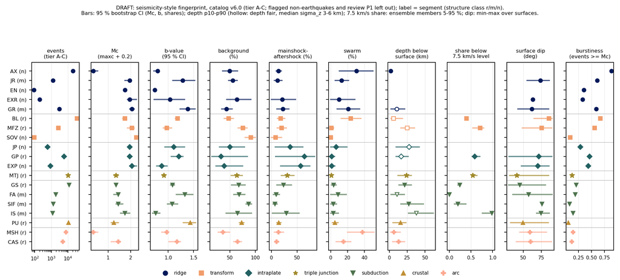

Seismicity-style fingerprint of the plate-boundary segments (mock-up of main figure 2). Label: segment code and structure class (r resolved, m marginal, n not resolved). Draft.

### Size, completeness, clustering

| seg | type | events | with M | Mmax | M≥4 | Mc | Mc lo | Mc hi | Mc map | b | b lo | b hi | n ≥ Mc | n clustering | bg % | bg lo | bg hi | MA % | swarm % | multiplet % | swarm % of clustered | MA fam | swarm fam | multiplet fam | swarm fam ≥10 | migrating (zbz) | DBSCAN swarm-like | migrating (DBSCAN) |
| --- | --- | --- | --- | --- | --- | --- | --- | --- | --- | --- | --- | --- | --- | --- | --- | --- | --- | --- | --- | --- | --- | --- | --- | --- | --- | --- | --- | --- |
| AX | ridge | 20,996 | 11,222 | 4.76 | 4 | 0.35 | 0.35 | 0.55 | 0.50 | 0.80 | 0.72 | 0.82 | 4,938 | 2,113 | 50 | 36 | 65 | 14 | 31 | 6 | 61 | 130 | 33 | 88 | 10 | 2 | 16 | 0 |
| JR | ridge | 1,267 | 748 | 5.62 | 1 | 1.95 | 1.75 | 1.95 | 1.70 | 1.29 | 1.09 | 1.53 | 198 | 362 | 56 | 48 | 65 | 12 | 13 | 19 | 30 | 16 | 9 | 37 | 0 | 0 | 1 | 0 |
| EN | ridge | 89 | 63 | 3.17 | 0 | 1.75 | – | – | 1.50 | 0.74 | – | – | 34 | 20 | – | – | – | – | – | – | – | 2 | 0 | 0 | 0 | 0 | 0 | 0 |
| EXR | ridge | 199 | 181 | 4.68 | 2 | 1.95 | 1.85 | 2.25 | 1.60 | 1.03 | 0.72 | 1.32 | 77 | 61 | 64 | 44 | 91 | 21 | 10 | 5 | 27 | 1 | 1 | 2 | 0 | 0 | 0 | 0 |
| GR | ridge | 3,096 | 2,268 | 5.53 | 5 | 2.05 | 1.95 | 2.15 | 2.00 | 1.39 | 1.24 | 1.53 | 624 | 354 | 43 | 34 | 55 | 22 | 21 | 14 | 37 | 14 | 7 | 19 | 4 | 1 | 18 | 0 |
| BL | transform | 36,665 | 29,538 | 5.95 | 32 | 1.75 | 1.65 | 1.75 | 1.50 | 1.19 | 1.14 | 1.21 | 8,885 | 8,877 | 48 | 39 | 57 | 18 | 24 | 10 | 46 | 285 | 95 | 379 | 28 | 3 | 165 | 10 |
| MFZ | transform | 2,742 | 2,163 | 6.60 | 12 | 2.05 | 1.85 | 2.15 | 1.80 | 0.98 | 0.90 | 1.07 | 673 | 651 | 76 | 66 | 84 | 20 | 1 | 3 | 4 | 33 | 1 | 11 | 0 | 0 | 1 | 0 |
| SOV | transform | 95 | 85 | 4.82 | 2 | 2.25 | – | – | 1.70 | – | – | – | 28 | 47 | 91 | 80 | 100 | 9 | 0 | 0 | 0 | 1 | 0 | 0 | 0 | 0 | 0 | 0 |
| JP | intraplate | 607 | 429 | 5.19 | 1 | 1.95 | 1.95 | 1.95 | 1.50 | 1.11 | 0.93 | 1.32 | 147 | 190 | 50 | 29 | 79 | 36 | 6 | 7 | 13 | 10 | 2 | 11 | 1 | 0 | 2 | 0 |
| GP | intraplate | 6,078 | 4,861 | 6.80 | 15 | 1.95 | 1.95 | 2.05 | 1.90 | 1.21 | 1.06 | 1.29 | 1,387 | 1,886 | 33 | 15 | 85 | 64 | 1 | 2 | 2 | 29 | 2 | 19 | 0 | 0 | 7 | 0 |
| EXP | intraplate | 875 | 822 | 6.53 | 12 | 2.05 | 1.95 | 2.25 | 2.00 | 0.87 | 0.77 | 0.98 | 393 | 403 | 39 | 23 | 76 | 57 | 1 | 3 | 2 | 17 | 1 | 5 | 0 | 0 | 2 | 0 |
| MTJ | triple junction | 10,574 | 9,049 | 5.88 | 21 | 1.35 | 1.25 | 1.45 | 1.30 | 0.92 | 0.88 | 0.95 | 4,294 | 2,313 | 64 | 52 | 75 | 31 | 1 | 4 | 3 | 115 | 4 | 43 | 0 | 0 | 4 | 1 |
| GS | subduction | 11,994 | 9,373 | 6.50 | 11 | 1.35 | 1.35 | 1.35 | 1.20 | 1.08 | 1.05 | 1.12 | 3,774 | 1,695 | 68 | 54 | 80 | 23 | 3 | 6 | 11 | 58 | 8 | 43 | 2 | 0 | 24 | 0 |
| FA | subduction | 1,871 | 1,539 | 6.41 | 1 | 1.45 | 1.25 | 1.45 | 1.20 | 1.33 | 1.16 | 1.49 | 444 | 169 | 69 | 58 | 79 | 9 | 9 | 13 | 28 | 7 | 2 | 10 | 1 | 0 | 2 | 0 |
| SIF | subduction | 1,354 | 1,215 | 4.00 | 1 | 1.45 | 1.35 | 1.65 | 1.20 | 1.08 | 0.99 | 1.19 | 531 | 395 | 87 | 82 | 93 | 7 | 3 | 3 | 24 | 9 | 1 | 4 | 0 | 0 | 0 | 0 |
| IS | subduction | 1,195 | 1,070 | 5.51 | 7 | 1.75 | 1.55 | 1.95 | 1.40 | 0.76 | 0.69 | 0.84 | 452 | 481 | 65 | 42 | 93 | 29 | 3 | 2 | 9 | 10 | 2 | 8 | 0 | 0 | 0 | 0 |
| PU | crustal | 11,376 | 10,969 | 3.95 | 0 | 1.25 | 1.15 | 1.45 | 1.10 | 1.44 | 1.30 | 1.55 | 3,924 | 2,823 | 74 | 69 | 78 | 14 | 5 | 7 | 19 | 113 | 12 | 88 | 5 | 0 | 9 | 0 |
| MSH | arc | 7,858 | 7,703 | 3.96 | 0 | 0.35 | 0.35 | 0.55 | 0.10 | 0.97 | 0.88 | 1.00 | 3,323 | 282 | 37 | 27 | 49 | 13 | 38 | 12 | 60 | 22 | 18 | 33 | 9 | 1 | 47 | 0 |
| CAS | arc | 5,107 | 5,014 | 4.10 | 1 | 1.45 | 1.15 | 1.55 | 0.80 | 1.17 | 1.01 | 1.25 | 1,148 | 1,012 | 65 | 58 | 73 | 10 | 15 | 9 | 43 | 32 | 11 | 42 | 9 | 0 | 8 | 0 |
| OC | other | 7,547 | 7,264 | 4.07 | 2 | 1.05 | 1.05 | 1.15 | 1.00 | 1.10 | 1.07 | 1.22 | 3,353 | 725 | 81 | 76 | 87 | 10 | 2 | 7 | 9 | 25 | 2 | 28 | 1 | 0 | 3 | 0 |
| NAPA | other | 4,369 | 3,587 | 5.69 | 6 | 1.35 | 1.25 | 1.55 | 1.20 | 0.87 | 0.83 | 0.92 | 1,682 | 959 | 76 | 69 | 81 | 13 | 2 | 9 | 9 | 46 | 3 | 42 | 0 | 0 | 2 | 0 |

### Depth and geometry

bsf = depth below the solid surface (ground or seafloor), depth-good events only (tier A-C, depth_quality ok, not floor-limited, far-only or deep-pass). For segments without depth-good events the raw median is given in the "unconstrained" column and should not be used. 7.5 and 8 km/s levels: depth of the first Vp crossing in the event's model column between two P-resolved nodes; "members p05/p95" = the share recomputed with each member's level (raw spread). Fault-surface columns: v1 surfaces of the segment (dip weighted by member count; seismogenic width = 2-98 % depth range of depth-ok members).

| seg | depth class | depth-good | median σz | bsf p10 | bsf p50 | p50 lo | p50 hi | bsf p90 | p90 lo | p90 hi | bsf p50 (unconstrained) | 7.5 km/s level bsf | share with level | below 7.5 | lo | hi | members p05 | members p95 | share with 8 km/s | below 8 | depth - Slab2 | dip (wtd) | dip min | dip max | seismogenic width | seismogenic bottom | share on surfaces |
| --- | --- | --- | --- | --- | --- | --- | --- | --- | --- | --- | --- | --- | --- | --- | --- | --- | --- | --- | --- | --- | --- | --- | --- | --- | --- | --- | --- |
| AX | good | 20,231 | 0.83 | 1.07 | 1.91 | 1.90 | 1.92 | 2.54 | 2.52 | 2.57 | – | – | 0.00 | – | – | – | – | – | 0.00 | – | – | – | – | – | – | – | – |
| JR | none | 0 | – | – | – | – | – | – | – | – | 0.80 | – | – | – | – | – | – | – | – | – | – | 73.93 | 55.50 | 86.30 | – | – | 0.08 |
| EN | none | 0 | – | – | – | – | – | – | – | – | 2.33 | – | – | – | – | – | – | – | – | – | – | – | – | – | – | – | – |
| EXR | none | 0 | – | – | – | – | – | – | – | – | 40.09 | – | – | – | – | – | – | – | – | – | – | 63.20 | 63.20 | 63.20 | – | – | 0.15 |
| GR | fair | 1,217 | 4.29 | 2.41 | 10.54 | 9.72 | 10.99 | 21.63 | 20.70 | 23.03 | – | – | 0.00 | – | – | – | – | – | 0.00 | – | – | 62.09 | 42.90 | 85.20 | 16.35 | 30.45 | 0.60 |
| BL | fair | 18,880 | 5.05 | 2.44 | 5.83 | 5.74 | 5.97 | 18.56 | 18.31 | 18.94 | – | 8.45 | 0.95 | 0.39 | 0.39 | 0.40 | 0.36 | 0.41 | 0.36 | 0.18 | – | 85.61 | 64.90 | 89.90 | 21.00 | 27.00 | 0.66 |
| MFZ | fair | 2,443 | 3.74 | 16.17 | 24.84 | 24.38 | 25.19 | 35.15 | 34.29 | 35.93 | – | 21.26 | 0.81 | 0.71 | 0.69 | 0.73 | 0.54 | 0.79 | 0.00 | – | – | 75.57 | 48.90 | 89.80 | 15.10 | 35.80 | 0.51 |
| SOV | none | 0 | – | – | – | – | – | – | – | – | 44.37 | – | – | – | – | – | – | – | – | – | – | – | – | – | – | – | – |
| JP | fair | 198 | 5.50 | 9.61 | 27.81 | 26.27 | 29.94 | 42.02 | 40.01 | 47.69 | – | – | 0.00 | – | – | – | – | – | 0.00 | – | – | – | – | – | – | – | – |
| GP | fair | 618 | 3.22 | 9.44 | 16.58 | 16.02 | 17.16 | 26.33 | 25.07 | 28.58 | – | 20.73 | 0.30 | 0.58 | 0.51 | 0.65 | 0.52 | 0.70 | 0.22 | 0.32 | – | 71.46 | 30.30 | 89.60 | 13.70 | 35.10 | 0.47 |
| EXP | none | 0 | – | – | – | – | – | – | – | – | 40.54 | – | – | – | – | – | – | – | – | – | – | 70.20 | 47.60 | 85.60 | – | – | 0.30 |
| MTJ | good | 10,437 | 1.77 | 11.97 | 24.13 | 24.00 | 24.28 | 30.95 | 30.87 | 31.04 | – | 21.96 | 0.97 | 0.54 | 0.53 | 0.55 | 0.52 | 0.63 | 0.50 | 0.64 | 10.85 | 41.28 | 31.20 | 85.30 | 19.65 | 30.35 | 0.64 |
| GS | good | 11,876 | 1.94 | 13.50 | 21.67 | 21.54 | 21.82 | 30.62 | 30.46 | 30.78 | – | 25.54 | 0.92 | 0.24 | 0.23 | 0.25 | 0.19 | 0.25 | 0.16 | 0.20 | 2.85 | 45.46 | 30.20 | 80.70 | 17.20 | 29.50 | 0.50 |
| FA | fair | 1,770 | 3.08 | 2.20 | 10.90 | 10.60 | 11.14 | 21.13 | 20.33 | 22.02 | – | 27.42 | 0.04 | 0.00 | 0.00 | 0.00 | 0.00 | 0.00 | 0.01 | – | -14.01 | 57.66 | 35.50 | 89.90 | 13.50 | 21.80 | 0.19 |
| SIF | good | 1,350 | 1.97 | 16.32 | 27.26 | 26.73 | 28.09 | 47.53 | 46.59 | 48.39 | – | 26.78 | 0.05 | 0.19 | 0.11 | 0.29 | 0.12 | 0.38 | 0.00 | – | 0.29 | 76.10 | 76.10 | 76.10 | 16.60 | 24.50 | 0.03 |
| IS | fair | 1,175 | 3.12 | 26.96 | 38.08 | 37.33 | 39.01 | 61.51 | 60.22 | 62.93 | – | 55.11 | 0.05 | 0.98 | 0.94 | 1.00 | 0.76 | 1.00 | 0.00 | – | 12.68 | 74.54 | 68.80 | 86.30 | 17.85 | 51.85 | 0.10 |
| PU | good | 11,027 | 2.29 | 5.09 | 15.69 | 15.55 | 15.83 | 23.37 | 23.16 | 23.62 | – | – | 0.00 | – | – | – | – | – | 0.00 | – | -33.81 | 49.52 | 32.70 | 84.60 | 11.60 | 22.10 | 0.28 |
| MSH | good | 7,603 | 1.06 | 1.99 | 6.19 | 6.16 | 6.27 | 15.32 | 15.22 | 15.35 | – | – | 0.00 | – | – | – | – | – | 0.00 | – | -55.51 | 59.51 | 45.20 | 82.30 | 13.85 | 18.00 | 0.65 |
| CAS | good | 4,980 | 2.32 | 4.51 | 12.93 | 12.70 | 13.14 | 21.58 | 21.34 | 21.95 | – | – | 0.00 | – | – | – | – | – | 0.00 | – | -59.71 | 60.46 | 40.60 | 89.30 | 11.90 | 17.05 | 0.24 |
| OC | good | 7,182 | 2.21 | 4.17 | 14.88 | 14.73 | 15.03 | 22.61 | 22.29 | 22.89 | – | 28.57 | 0.03 | 0.00 | 0.00 | 0.00 | 0.00 | 0.00 | 0.00 | 0.00 | -32.67 | 53.99 | 31.50 | 79.60 | 10.80 | 21.60 | 0.28 |
| NAPA | good | 4,246 | 2.01 | 6.00 | 23.14 | 22.80 | 23.36 | 32.44 | 32.33 | 32.63 | – | 32.45 | 0.28 | 0.28 | 0.25 | 0.31 | 0.18 | 0.53 | 0.00 | – | -0.41 | 55.34 | 37.80 | 76.90 | 12.05 | 23.20 | 0.47 |

### Temporal character

Events ≥ the segment Mc over the whole period. COV = coefficient of variation of inter-event times (1 for a Poisson process); burstiness = (σ − μ)/(σ + μ). The network changed with the OBS deployments (2011-2015) and Axial enters tier A-C only from 2013-09, so rates and burstiness compare segments only roughly.

| seg | first | last | years | events ≥ Mc per yr | COV all | burstiness all | COV bg | burstiness bg | share on busiest 1 % of days | largest family / events |
| --- | --- | --- | --- | --- | --- | --- | --- | --- | --- | --- |
| AX | 2013-09-05 | 2016-12-31 | 4 | 1619 | 15.80 | 0.88 | 13.07 | 0.86 | 0.29 | 0.02 |
| JR | 2010-08-01 | 2016-12-21 | 7 | 34 | 4.08 | 0.61 | 2.80 | 0.47 | 0.36 | 0.03 |
| EN | 2011-12-03 | 2016-08-06 | 6 | 7 | 2.09 | 0.35 | 1.61 | 0.23 | 0.76 | 0.24 |
| EXR | 2010-01-12 | 2016-09-17 | 7 | 12 | 1.99 | 0.33 | 1.59 | 0.23 | 0.57 | 0.05 |
| GR | 2010-08-07 | 2015-09-11 | 6 | 122 | 3.90 | 0.59 | 3.04 | 0.51 | 0.32 | 0.03 |
| BL | 2010-01-09 | 2016-12-23 | 7 | 1278 | 5.02 | 0.67 | 3.53 | 0.56 | 0.20 | 0.04 |
| MFZ | 2010-01-03 | 2016-12-08 | 7 | 97 | 3.57 | 0.56 | 1.33 | 0.14 | 0.15 | 0.14 |
| SOV | 2010-07-29 | 2016-12-09 | 7 | 5 | 1.21 | 0.09 | 1.09 | 0.04 | 0.82 | 0.04 |
| JP | 2010-04-11 | 2016-09-11 | 7 | 23 | 1.80 | 0.29 | 1.57 | 0.22 | 0.32 | 0.21 |
| GP | 2010-01-06 | 2016-12-06 | 7 | 201 | 2.72 | 0.46 | 2.28 | 0.39 | 0.32 | 0.41 |
| EXP | 2010-03-25 | 2016-06-09 | 7 | 63 | 2.57 | 0.44 | 1.47 | 0.19 | 0.50 | 0.31 |
| MTJ | 2010-01-01 | 2016-01-10 | 7 | 713 | 1.29 | 0.13 | 1.34 | 0.15 | 0.09 | 0.06 |
| GS | 2010-01-02 | 2016-04-24 | 7 | 598 | 1.53 | 0.21 | 1.34 | 0.15 | 0.08 | 0.15 |
| FA | 2010-01-05 | 2016-12-25 | 7 | 64 | 1.46 | 0.19 | 1.36 | 0.15 | 0.16 | 0.03 |
| SIF | 2010-01-14 | 2016-12-26 | 7 | 77 | 1.18 | 0.08 | 1.12 | 0.06 | 0.13 | 0.01 |
| IS | 2010-01-02 | 2016-12-25 | 7 | 65 | 1.34 | 0.15 | 1.05 | 0.02 | 0.29 | 0.26 |
| PU | 2010-01-01 | 2016-12-31 | 7 | 561 | 1.11 | 0.05 | 1.04 | 0.02 | 0.05 | 0.02 |
| MSH | 2010-01-01 | 2016-12-30 | 7 | 475 | 1.33 | 0.14 | 1.20 | 0.09 | 0.12 | 0.05 |
| CAS | 2010-01-01 | 2016-12-28 | 7 | 164 | 1.27 | 0.12 | 1.08 | 0.04 | 0.12 | 0.01 |
| OC | 2010-01-02 | 2016-12-29 | 7 | 480 | 1.19 | 0.09 | 1.15 | 0.07 | 0.06 | 0.01 |
| NAPA | 2010-01-02 | 2016-03-09 | 7 | 272 | 1.66 | 0.25 | 1.50 | 0.20 | 0.09 | 0.01 |

## 5. Figure plan

Six main figures, each a set of small multiples with segments on a shared axis and one colour or marker per boundary type (ridge, transform, intraplate, triple junction, subduction, crustal, arc). Velocity appears only in figures 4 and 5 and only on resolved nodes near the segments. All on catalog v6.1 and model v0.4.2.

[output not shown]

**Supplement.** S1 segment rule and threshold sensitivity (sec. 7); S2 Mc maps, three methods and by period (current fig2a, fig2b, on v6.1 without flagged events, D-B105); S3 catalog comparison (current figS); S4 nearest-neighbour density plots by segment type (current fig5 A-C, regrouped); S5 structure feasibility: node counts, checkerboard share and ensemble 1σ maps limited to the segment areas; S6 five individual ensemble members of the BL and MFZ sections (what the 1σ means); S7 Mendocino perspective view (current perspective_mendocino_fault); S8 migrating swarms (Blanco 3 zbz + 10 DBSCAN, Axial 2, Gorda ridge 1, Mount St Helens 1); S9 the unresolved boundaries (Axial, Endeavour, Explorer, JdF plate): seismicity-only panels.

**Leaves the main text:** fig2a and fig2b (Mc maps) move to the supplement; fig5 A-C move to S4; fig4 becomes a panel of figure 3 or moves to the supplement. No full-size velocity maps or margin-normal model sections (D-B107).

## 6. Mock-up: fault-normal sections, Blanco and Mendocino fault zone

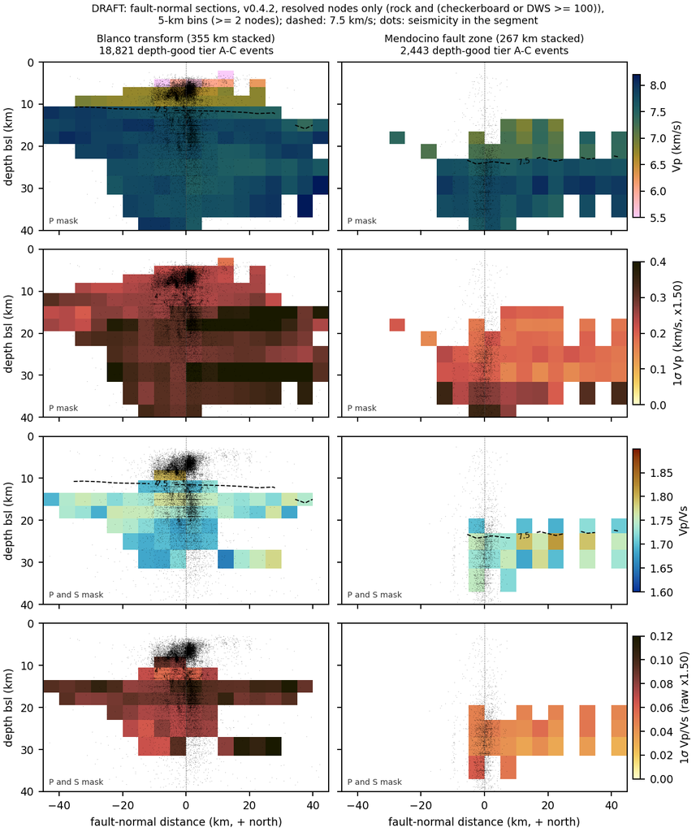

Model v0.4.2 on resolved nodes in 5 km bins of fault-normal distance (≥ 2 nodes per bin), stacked along 355 km (Blanco) and 267 km (MFZ) of the PB2002 transform trace and centred on the seismicity (trace offset -5.2 km and +7.9 km). Rows: Vp, its 1σ (x1.50), Vp/Vs (P and S mask), its 1σ (raw x1.50). Dots: depth-good tier A-C events of the segment. Dashed: 7.5 km/s. Draft.

### Depth extent against the velocity level, per model column

| seg | level | n_columns | median D90 − level (km) | Spearman ρ | sd(D90 − level) | null sd (median) | p | sd D90 | sd level |
| --- | --- | --- | --- | --- | --- | --- | --- | --- | --- |
| BL | z75 | 55 | 8.84 | 0.12 | 6.84 | 7.17 | 0.046 | 7.11 | 1.34 |
| BL | z8 | 28 | 3.42 | -0.07 | 9.69 | 10.71 | 0.159 | 6.93 | 8.44 |
| GS | z75 | 64 | 3.10 | 0.52 | 4.04 | 5.69 | 0.001 | 4.90 | 2.96 |
| GS | z8 | 15 | 2.20 | -0.36 | 5.20 | 4.45 | 0.930 | 3.62 | 2.78 |
| MFZ | z75 | 16 | 12.95 | 0.19 | 3.38 | 3.53 | 0.314 | 3.46 | 1.14 |
| MTJ | z75 | 27 | 9.63 | 0.01 | 3.96 | 3.54 | 0.912 | 2.94 | 2.12 |
| MTJ | z8 | 17 | 6.19 | 0.51 | 2.00 | 3.02 | 0.008 | 2.51 | 1.87 |
| NAPA | z75 | 10 | 3.69 | 0.16 | 2.29 | 4.66 | 0.040 | 3.52 | 3.20 |

Columns with ≥ 20 depth-good events and a resolved level. p = share of 1000 permutations of the level among the segment's columns with a smaller sd(D90 − level).

### Swarm against mainshock-aftershock families on resolved nodes

| seg | var | n_swarm | n_MA | n_multiplet | swarm − MA (median) | null 2.5 % | null 97.5 % | p | σ members |
| --- | --- | --- | --- | --- | --- | --- | --- | --- | --- |
| BL | VpVs | 9 | 32 | 24 | -0.000 | -0.036 | +0.058 | 1.00 | 0.041 |
| BL | Vp | 28 | 68 | 57 | +0.025 | -0.069 | +0.050 | 0.75 | 0.081 |
| CAS | VpVs | 0 | 4 | 1 | – | – | – | – | – |
| CAS | Vp | 5 | 5 | 3 | -0.106 | -0.106 | -0.106 | 1.00 | 0.328 |
| FA | Vp | 2 | 2 | 2 | – | – | – | – | – |
| GP | Vp | 0 | 1 | 1 | – | – | – | – | – |
| GR | Vp | 3 | 2 | 2 | – | – | – | – | – |
| GS | VpVs | 3 | 24 | 8 | – | – | – | – | – |
| GS | Vp | 4 | 28 | 10 | – | – | – | – | – |
| IS | Vp | 2 | 1 | 0 | – | – | – | – | – |
| MFZ | VpVs | 0 | 6 | 0 | – | – | – | – | – |
| MFZ | Vp | 1 | 9 | 0 | – | – | – | – | – |
| MSH | VpVs | 13 | 3 | 4 | – | – | – | – | – |
| MSH | Vp | 13 | 4 | 5 | – | – | – | – | – |
| MTJ | VpVs | 3 | 39 | 3 | – | – | – | – | – |
| MTJ | Vp | 4 | 43 | 3 | – | – | – | – | – |
| NAPA | VpVs | 0 | 6 | 3 | – | – | – | – | – |
| NAPA | Vp | 1 | 7 | 3 | – | – | – | – | – |
| OC | VpVs | 0 | 5 | 2 | – | – | – | – | – |
| OC | Vp | 0 | 10 | 3 | – | – | – | – | – |
| PU | VpVs | 7 | 13 | 10 | +0.023 | -0.033 | +0.035 | 0.22 | 0.022 |
| PU | Vp | 12 | 30 | 16 | +0.088 | -0.137 | +0.078 | 0.11 | 0.073 |
| SIF | Vp | 1 | 1 | 0 | – | – | – | – | – |

Families with ≥ 5 depth-good members, placed at the node nearest their median position. Null: type labels permuted among families of the same depth layer (2000 draws). σ members: the same difference in each member x calibration factor.

## 7. Caveats

- Catalog v6.0, not v6.1: Axial depths about 0.2 km too deep and the SSST depth drift elsewhere (Puget, Blanco) (D-B100, D-B103); magnitudes are the converged values of the v5.1 hypocentres (D-B105). The paper text is still on v4.1. Every number here moves with v6.1.
- No structure for Axial, Endeavour and Explorer (outside every tomography tile) or the JdF plate interior (tile edges, DWS below 100).
- Resolution: 40 km checkerboard cells and a 10 km node grid. Most nodes near the faults pass the mask on DWS ≥ 100 only, which shows ray sampling, not resolution. Ray coverage follows the seismicity, so velocity near events can be biased in the same place the events are (the v5.1 checkerboard-error control has to be repeated on v0.4.2 before any contrast is interpreted).
- Uncertainty: the ensemble 1σ for Vp and Vs is calibrated (x 1.50, x 1.35; D-B099); Vp/Vs has no calibrated factor (raw x 1.50 assumed here). The member spread does not include smoothing bias from limited resolution.
- Depths: the ridges other than Axial, Explorer and the JdF plate have depth_quality unconstrained; Gorda events are mostly biased_deep (618 depth-good of 6,078 Gorda-plate events); Blanco depth-good events have median σz 5 km and a deep tail against Lange et al. (2026). Depth rows are marked fair or none accordingly.
- Segment rule: PB2002 traces are approximate (MFZ seismicity lies 8 km north of the trace, Blanco 5 km south); the thresholds (MTJ radius, axis half-width, 41.5 N, ±5 km about Slab2) are choices. MTJ changes from 6,745 to 14,134 events between radii of 30 and 50 km; the interface-zone group SIF from 885 to 1,871 between ±3 and ±8 km.
- Fault surfaces v1 were fitted on v5.1 positions; only 42 of 130 non-strand surfaces are stable under detection reruns (v1 README). Dips and widths here are descriptive.
- Clustering: the v6.0 run used its own regional Mc (AX, EN, BL, GO, MT, WA, OR, PU, ON), not the segment Mc; it read an earlier file of v6.0 (md5 0daf4880…) whose positions, magnitudes and tiers are identical to the current file (checked here). Bootstrap intervals ignore correlation in time.
- Temporal metrics depend on network changes; they are rough comparisons only.

### Threshold sensitivity (tier A-C events per segment)

| seg | default | R_MTJ_KM=30.0 | R_MTJ_KM=50.0 | D_AXIS_KM=10.0 | D_AXIS_KM=20.0 | LAT_GS=41.0 | LAT_GS=42.0 | SLAB_IF_KM=3.0 | SLAB_IF_KM=8.0 |
| --- | --- | --- | --- | --- | --- | --- | --- | --- | --- |
| AX | 20,996 | 20,996 | 20,996 | 20,996 | 20,996 | 20,996 | 20,996 | 20,996 | 20,996 |
| JR | 1,267 | 1,267 | 1,267 | 1,019 | 1,542 | 1,267 | 1,267 | 1,267 | 1,267 |
| EN | 89 | 89 | 89 | 89 | 89 | 89 | 89 | 89 | 89 |
| EXR | 199 | 199 | 199 | 105 | 275 | 199 | 199 | 199 | 199 |
| GR | 3,096 | 3,096 | 3,096 | 2,340 | 3,763 | 3,096 | 3,096 | 3,096 | 3,096 |
| BL | 36,665 | 36,665 | 36,665 | 36,665 | 36,665 | 36,665 | 36,665 | 36,665 | 36,665 |
| MFZ | 2,742 | 2,894 | 2,633 | 2,126 | 3,131 | 2,742 | 2,742 | 2,742 | 2,742 |
| SOV | 95 | 95 | 95 | 73 | 197 | 95 | 95 | 95 | 95 |
| JP | 607 | 607 | 607 | 853 | 332 | 607 | 607 | 607 | 607 |
| GP | 6,078 | 6,205 | 5,981 | 7,449 | 5,024 | 6,078 | 6,078 | 6,078 | 6,078 |
| EXP | 875 | 875 | 875 | 993 | 697 | 875 | 875 | 875 | 875 |
| MTJ | 10,574 | 6,745 | 14,134 | 10,574 | 10,574 | 10,574 | 10,574 | 10,574 | 10,574 |
| GS | 11,994 | 14,281 | 9,212 | 11,994 | 11,994 | 11,252 | 12,125 | 11,994 | 11,994 |
| FA | 1,871 | 1,871 | 1,871 | 1,871 | 1,871 | 1,958 | 1,800 | 2,062 | 1,646 |
| SIF | 1,354 | 1,354 | 1,354 | 1,354 | 1,354 | 1,722 | 1,337 | 885 | 1,871 |
| IS | 1,195 | 1,195 | 1,195 | 1,195 | 1,195 | 1,482 | 1,152 | 1,473 | 903 |
| PU | 11,376 | 11,376 | 11,376 | 11,376 | 11,376 | 11,376 | 11,376 | 11,376 | 11,376 |
| MSH | 7,858 | 7,858 | 7,858 | 7,858 | 7,858 | 7,858 | 7,858 | 7,858 | 7,858 |
| CAS | 5,107 | 5,107 | 5,107 | 5,107 | 5,107 | 5,107 | 5,107 | 5,107 | 5,107 |
| OC | 7,547 | 7,547 | 7,547 | 7,547 | 7,547 | 7,547 | 7,547 | 7,547 | 7,547 |
| NAPA | 4,369 | 5,632 | 3,797 | 4,370 | 4,367 | 4,369 | 4,369 | 4,369 | 4,369 |

## 8. Reproduce

Worktree /home/mdenolle/wt_pbplan, branch analysis/plate-boundaries (from origin/main 5b42fcd2). Python:

```
LD_LIBRARY_PATH=/home/mdenolle/cascadia_obs_ensemble/.pixi/envs/default/lib
/home/mdenolle/cascadia_obs_ensemble/.pixi/envs/default/bin/python
```

, nice 10, one process. In `workflow/11_paper_plan/`: `pb_structure.py` (events with segments, levels, feasibility, contrasts; about 40 s), `pb_seismicity.py`, `pb_struct_seis.py`, `pb_sensitivity.py`, `pb_figures.py`, `pb_page.py "$(date)"`. Small tables: `data/paper_plan/plate_boundaries/`; page, figures and the event table: /wd1/mdenolle_data/paper_plan/. Colour helpers: `workflow/08_figures/scm_palettes.py` (copy of paper/model-figures 7aea31dd).

- catalog v6.0: `/wd1/mdenolle_data/catalog_v6/v6.0/cascadia_catalog_v6.0.csv` (md5 923aa0622d5dc62929240b58b5a52636)
- clustering events: `/wd1/mdenolle_data/catalog_v6/v6.0_analysis/clusters/events_zbz_v60.csv.gz` (md5 62333c539956c5fbc5ca74309d9edf9b)
- clustering families: `/wd1/mdenolle_data/catalog_v6/v6.0_analysis/clusters/families_zbz_v60.csv` (md5 5e144fbac7cecc0aa51d122fd0c37620)
- Mc map v6.0: `/wd1/mdenolle_data/magnitude_converged/mc_maps_v60/mc_grid.csv` (md5 c32338579d88f448966e3775bcdde710)
- model v0.4.2: `/wd1/mdenolle_data/tomo_v1/models/cascadia_obs_tomo/v0.4.2.nc` (md5 6cd65a101c12e827b00b7c13b0e32e2f)
- ensemble v0.4.2+ens.100: `/wd1/mdenolle_data/tomo_v1/models/cascadia_obs_tomo/v0.4.2+ens.100.nc` (md5 0408277b95ae133820afe74f00b99d76)
- fault surfaces v1 mesh: `/wd1/mdenolle_data/catalog_v5/v5.1_analysis/faults/fault_surfaces_v1_vertices.csv.gz` (md5 6a3750ebd00723b27a432bb0b777c027)
- fault surfaces v1 summary: `/home/mdenolle/wt_pbplan/data/catalog_v5/v5.1_analysis/faults/fault_surfaces_v1_summary.csv` (md5 eb69956273f3f7e4aa10fb2777277210)